# R Notebook

```r
library(lme4)
library(data.table)
library(R.utils)
library(stringr)
library(ggcorrplot)
```

# Check the DE resutls from MAST analysis

## Histogram of p-values

Histogram of p-values for each comparison

```r
mast_pval_df = read.csv("./output/MastGenePvals_by_CellType.csv",
                        header = TRUE, row.names = 1, as.is=TRUE)
head(mast_pval_df)
```

|  | gene | B_cells | CD4T_memory | CD8T_B | CD8T_G | Dendritic_cells | Monocytes_Macrophages | NK1 | NK2 | NK3 | Plasma_cells | Tregs |
| --- | --- | --- | --- | --- | --- | --- | --- | --- | --- | --- | --- | --- |
| 1 | DPM1 | 0.179163642 | 7.898076e-02 | 3.637704e-03 | 6.624228e-01 | 3.356444e-01 | 9.275798e-02 | 7.572004e-01 | 2.939882e-03 | 7.031104e-01 | 6.231445e-38 | 5.701770e-02 |
| 2 | SCYL3 | 0.650856626 | 1.948108e-02 | 6.222695e-03 | 2.184442e-02 | 1.273353e-01 | 1.126847e-12 | 3.744779e-05 | 3.151574e-02 | 1.623306e-01 | 6.159582e-06 | 6.963680e-01 |
| 3 | C1orf112 | 0.589807233 | 8.969903e-01 | 1.105883e-10 | 5.624144e-11 | 1.396408e-04 | 1.669722e-57 | 2.556339e-27 | 2.511303e-02 | 9.684203e-01 | 1.972988e-05 | 1.436925e-21 |
| 4 | FGR | 0.006770021 | 5.535000e-43 | 1.142280e-68 | 5.223656e-11 | 4.779863e-07 | 0.000000e+00 | 1.156553e-67 | 2.303466e-13 | 2.087945e-08 | 1.815466e-24 | 2.719524e-69 |
| 5 | FUCA2 | 0.013246054 | 1.104535e-01 | 6.189461e-19 | 2.549454e-05 | 1.157257e-02 | 3.112322e-81 | 8.360273e-21 | 4.149951e-04 | 1.366230e-03 | 4.839365e-54 | 1.278209e-01 |
| 6 | GCLC | 0.692705502 | 6.191272e-02 | 8.372299e-02 | 6.859598e-02 | 2.038311e-02 | 1.541764e-02 | 6.680221e-02 | 2.726769e-04 | 5.830243e-01 | 2.186322e-01 | 3.667960e-01 |

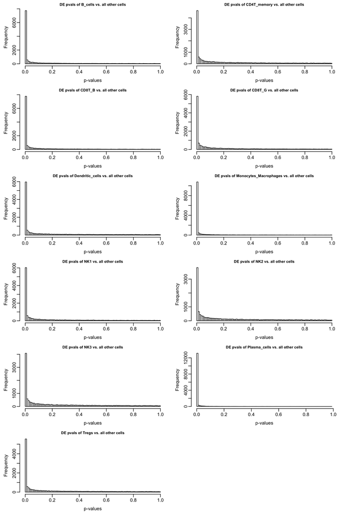

```r
par(mgp=c(2,0.5,0), mar=c(3.5,3.5,1.5,1), cex.main=0.8)
layout(matrix(1:12,nrow=6,ncol = 2,byrow = TRUE))
for (i in 2:ncol(mast_pval_df)) {
  cti = names(mast_pval_df)[i]
  hist(mast_pval_df[,i], xlab = "p-values", breaks = 100,
       main = paste("DE pvals of", cti, "vs. all other cells"))
}

par(mgp=c(2,0.5,0), mar=c(3.5,3.5,1.5,1), cex.main=0.8)
layout(matrix(1:12,nrow=6,ncol = 2,byrow = TRUE))
```

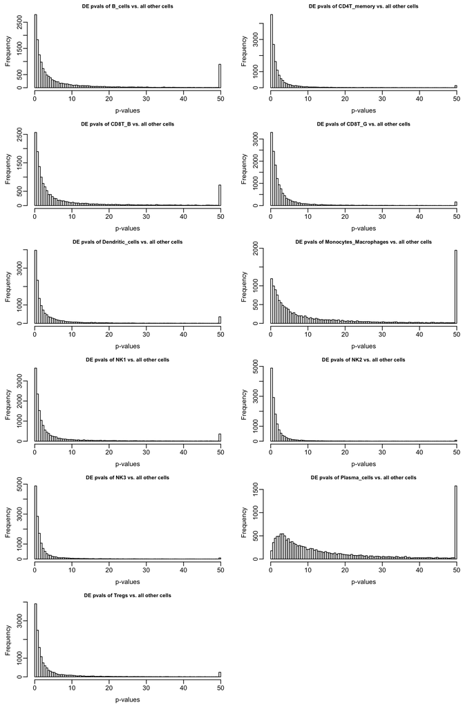

```r
for (i in 2:ncol(mast_pval_df)) {
  cti = names(mast_pval_df)[i]
  pvi = mast_pval_df[,i]
  pvi[which(pvi < 1e-50)] = 1e-50
  hist(-log10(pvi), xlab = "p-values", breaks = 100,
       main = paste("DE pvals of", cti, "vs. all other cells"))
}
```

## Volcano plot of p-values for each comparison

Read in dataframe of fold changes.

```r
fc_df = read.table("./output/Average_GeneExpression_by_CellType.txt",
                   header = TRUE, sep = "\t", as.is=TRUE)
head(fc_df)
```

|  | gene | u_B_cells | o_B_cells | fc_B_cells | u_CD4T_memory | o_CD4T_memory | fc_CD4T_memory | u_CD8T_B | o_CD8T_B | fc_CD8T_B | u_CD8T_G | o_CD8T_G | fc_CD8T_G | u_Dendritic_cells | o_Dendritic_cells | fc_Dendritic_cells | u_Monocytes_Macrophages | o_Monocytes_Macrophages | fc_Monocytes_Macrophages | u_NK1 | o_NK1 | fc_NK1 | u_NK2 | o_NK2 | fc_NK2 | u_NK3 | o_NK3 | fc_NK3 | u_Plasma_cells | … |
| --- | --- | --- | --- | --- | --- | --- | --- | --- | --- | --- | --- | --- | --- | --- | --- | --- | --- | --- | --- | --- | --- | --- | --- | --- | --- | --- | --- | --- | --- | --- |
| 1 | DPM1 | 0.7830764 | 1.2062171 | 1.540357 | 0.67016379 | 1.2051238 | 1.7982527 | 1.5418432 | 1.0930486 | 0.7089233 | 0.7940514 | 1.2624835 | 1.589927 | 1.9224555 | 1.1497714 | 0.5980744 | 2.1232932 | 1.0682170 | 0.50309445 | 2.6700658 | 1.1159746 | 0.4179577 | 0.7862213 | 1.2236843 | 1.5564121 | 1.2595529 | 1.1569698 | 0.9185559 | 1.07447183 | … |
| 2 | SCYL3 | 0.3497547 | 0.3863017 | 1.104493 | 0.43416742 | 0.3785102 | 0.8718071 | 0.5122222 | 0.3581116 | 0.6991333 | 0.2758696 | 0.4109037 | 1.489486 | 0.6611032 | 0.3772313 | 0.5706088 | 0.3249098 | 0.3885341 | 1.19582161 | 0.8091667 | 0.3689125 | 0.4559166 | 0.2478684 | 0.4037312 | 1.6288126 | 0.4697536 | 0.3756224 | 0.7996157 | 0.14549296 | … |
| 3 | C1orf112 | 0.2432936 | 0.3857010 | 1.585331 | 0.22873521 | 0.3834169 | 1.6762477 | 0.6096296 | 0.3265308 | 0.5356217 | 0.1148913 | 0.4394864 | 3.825237 | 0.1962633 | 0.3751854 | 1.9116430 | 0.3573459 | 0.3731762 | 1.04429969 | 2.1012500 | 0.3157474 | 0.1502665 | 0.1624834 | 0.4043384 | 2.4884901 | 0.3726460 | 0.3716538 | 0.9973374 | 0.05507042 | … |
| 4 | FGR | 0.8581219 | 1.0163681 | 1.184410 | 0.04146497 | 1.0792614 | 26.0282712 | 0.4124246 | 1.1126321 | 2.6977829 | 0.4061462 | 1.1577320 | 2.850530 | 0.5677936 | 1.0093732 | 1.7777115 | 6.0851579 | 0.4891010 | 0.08037605 | 0.2756579 | 1.0243143 | 3.7158896 | 1.0038756 | 1.0003688 | 0.9965067 | 0.6183120 | 1.0320174 | 1.6690883 | 0.07809859 | … |
| 5 | FUCA2 | 0.3019411 | 0.8104475 | 2.684124 | 0.36151046 | 0.7931729 | 2.1940525 | 0.6444358 | 0.7826158 | 1.2144200 | 0.2580171 | 0.8931326 | 3.461524 | 0.8217794 | 0.7593487 | 0.9240299 | 3.2285188 | 0.5121523 | 0.15863382 | 1.3761842 | 0.7406282 | 0.5381752 | 0.3940541 | 0.8176723 | 2.0750256 | 0.5309124 | 0.7792705 | 1.4677949 | 1.53447183 | … |
| 6 | GCLC | 0.2261668 | 0.2927247 | 1.294287 | 0.16429481 | 0.2961584 | 1.8026036 | 0.2743583 | 0.2884430 | 1.0513367 | 0.2609157 | 0.2928632 | 1.122444 | 0.5704626 | 0.2805938 | 0.4918707 | 0.4610451 | 0.2685954 | 0.58257950 | 0.3333114 | 0.2846692 | 0.8540639 | 0.3215145 | 0.2806898 | 0.8730237 | 0.2537591 | 0.2888377 | 1.1382359 | 0.22542254 | … |

```r
types = names(mast_pval_df)[-1]
types
```

```
##  [1] "B_cells"               "CD4T_memory"           "CD8T_B"
##  [4] "CD8T_G"                "Dendritic_cells"       "Monocytes_Macrophages"
##  [7] "NK1"                   "NK2"                   "NK3"
## [10] "Plasma_cells"          "Tregs"
```

```r
table(fc_df$gene == mast_pval_df$gene)
```

```
##
##  TRUE
## 14598
```

```r
fc_df = merge(fc_df, mast_pval_df, by="gene")
```

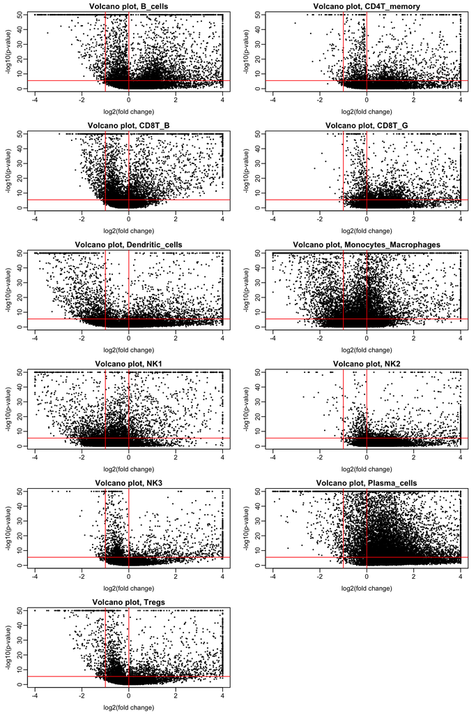

```r
par(mgp=c(2,0.5,0), mar=c(3.5,3.5,1.5,1))
layout(matrix(1:12,nrow=6,ncol = 2,byrow = TRUE))

for (i in 1:length(types)) {
  cti  = types[i]
  pval = fc_df[[cti]]
  pval[which(pval < 1e-50)] = 1e-50
  log2_fc = log2(fc_df[[paste0("fc_",cti)]])
  log2_fc[which(log2_fc > 4)] = 4
  log2_fc[which(log2_fc < -4)] = -4

  plot(log2_fc, -log10(pval),
       main = paste0("Volcano plot, ", types[i]),
       xlab = "log2(fold change)", ylab = "-log10(p-value)",
       xlim = c(-4,4), ylim = c(0, 50), cex=0.4, pch=20)
  abline(h=-log10(0.05/nrow(mast_pval_df)),col="red")
  abline(v=log2(1), col="red")
  abline(v=log2(1/2), col="red")
}
```

# Select differentially expressed genes for each cell type

Summarize the fold changes and mean expression for each gene. Find the minimum fc change for each gene.

```r
fc_cols = grep("^fc_", names(fc_df), value=TRUE)
u_cols  = grep("^u_", names(fc_df), value=TRUE)

apply(fc_df[,fc_cols], 2, function(v){table(v < 0.5)})
```

```
##       fc_B_cells fc_CD4T_memory fc_CD8T_B fc_CD8T_G fc_Dendritic_cells
## FALSE      14012          14473     13941     14572              12547
## TRUE         586            125       657        26               2051
##       fc_Monocytes_Macrophages fc_NK1 fc_NK2 fc_NK3 fc_Plasma_cells fc_Tregs
## FALSE                    10861  10048  14552  14469           14043    14192
## TRUE                      3737   4550     46    129             555      406
```

```r
apply(fc_df[,fc_cols], 2, function(v){table(v < 0.6)})
```

```
##       fc_B_cells fc_CD4T_memory fc_CD8T_B fc_CD8T_G fc_Dendritic_cells
## FALSE      13721          14308     13116     14502              11425
## TRUE         877            290      1482        96               3173
##       fc_Monocytes_Macrophages fc_NK1 fc_NK2 fc_NK3 fc_Plasma_cells fc_Tregs
## FALSE                     9274   7626  14508  14214           13771    13844
## TRUE                      5324   6972     90    384             827      754
```

```r
fc_mtrx = fc_df[,fc_cols]
min_fc  = apply(fc_mtrx, 1, min)
summary(min_fc)
```

```
##      Min.   1st Qu.    Median      Mean   3rd Qu.      Max.
## 0.0009404 0.3277871 0.4556157 0.4475076 0.5849110 0.9736193
```

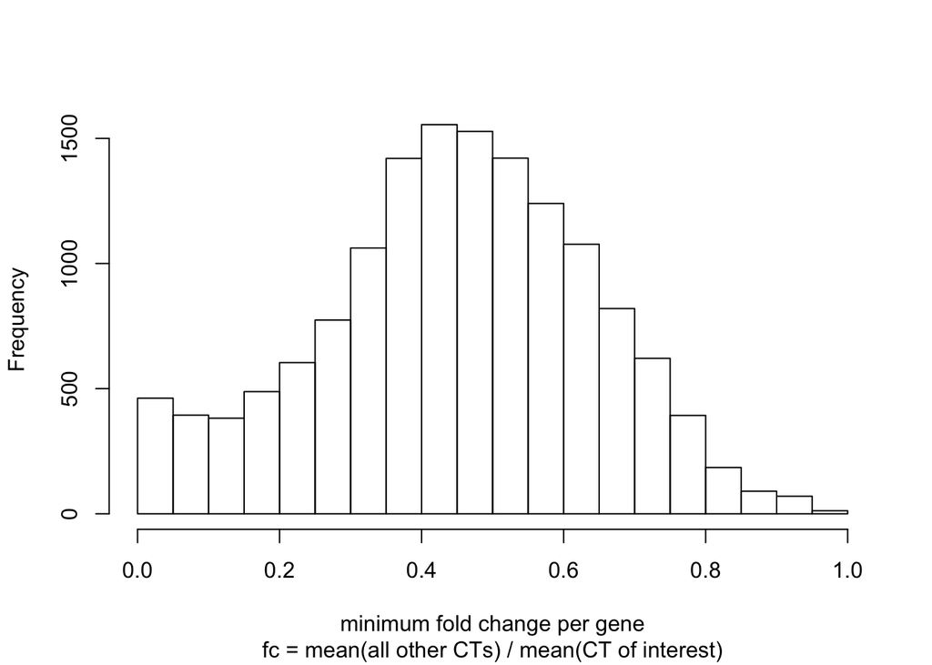

```r
hist(min_fc, xlab="minimum fold change per gene", main="",
     sub="fc = mean(all other CTs) / mean(CT of interest)")
```

```r
u_mtrx = fc_df[,u_cols]
u_mtrx[u_mtrx < 1e-3] = 1e-3
u_mtrx = log10(u_mtrx)
cr_mtrx = cor(u_mtrx, use="pair", method = "spearman")
summary(c(cr_mtrx))
```

```
##    Min. 1st Qu.  Median    Mean 3rd Qu.    Max.
##  0.6734  0.7399  0.8020  0.8334  0.9340  1.0000
```

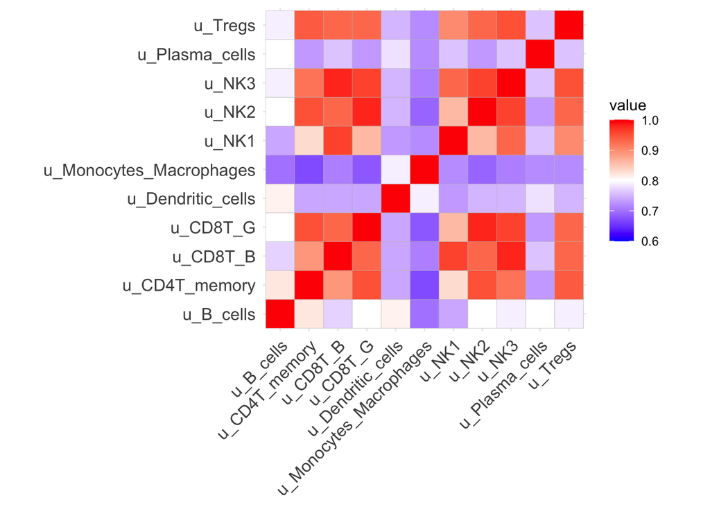

```r
ggcorrplot(cr_mtrx) +
  scale_fill_gradient2(limit = c(0.6,1), low = "blue", high = "red",
                       mid = "white", midpoint = 0.8)
```

Select around 60 genes per cell type.

1. First, for each cell type, pre-filter genes with p-value passing the Bonferroni threshold, and fold chnage smaller than 0.5 or fold change < 0.75 while it is the minimum fold change across all cell types.
2. Among those pre-filtered genes, select those genes with smallest p-value and fold change, by scanning a series of percentiles.

Here fold changes is defined as the raio between the average expression from other cell types versus the average expression of the cell type of interest. For example, for 1 percentile, we select the intersection of the genes with p-value < 1 percentile and fold change smaller than 1 percentile. We choose the percentile that gives us around 60 genes.

```r
qs = seq(0.001, 1, by=0.001)

q2use = n2choose = rep(NA, 11)

for (i in 1:11) {
  cti = types[i]

  fc_i = fc_df[,paste0("fc_", cti)]
  pv_i = fc_df[[cti]]

  w2use_fc = fc_i < 0.5 | (fc_i == min_fc & fc_i < 0.75)
  w2use_v0 = which(pv_i < 0.05/nrow(mast_pval_df) & w2use_fc)

  fc_i = fc_i[w2use_v0]
  pv_i = pv_i[w2use_v0]

  ni = rep(NA, length(qs))

  for(j in 1:length(qs)){
    qj = qs[j]
    ni[j] = sum(fc_i <= quantile(fc_i, probs=qj) &
                  pv_i <=  quantile(pv_i, probs=qj))
  }
  q2use[i]    = qs[which.min(abs(ni - 60))]
  n2choose[i] = ni[which.min(abs(ni - 60))]
}
data.frame(types, q2use, n2choose)
```

| types | q2use | n2choose |
| --- | --- | --- |
| B_cells | 0.138 | 60 |
| CD4T_memory | 0.519 | 60 |
| CD8T_B | 0.243 | 59 |
| CD8T_G | 0.940 | 59 |
| Dendritic_cells | 0.067 | 59 |
| Monocytes_Macrophages | 0.037 | 60 |
| NK1 | 0.082 | 59 |
| NK2 | 0.954 | 59 |
| NK3 | 0.630 | 59 |
| Plasma_cells | 0.216 | 60 |

[output cut: 1 more lines]

```r
genes.selected.perCellType = list()

for (i in 1:11) {
  cti = types[i]

  fc_i = fc_df[,paste0("fc_",cti)]
  pv_i = fc_df[[cti]]

  w2use_fc = fc_i < 0.5 | (fc_i == min_fc & fc_i < 0.75)
  w2use_v0 = which(pv_i < 0.05/nrow(mast_pval_df) & w2use_fc)

  fc_i = fc_i[w2use_v0]
  pv_i = pv_i[w2use_v0]

  fc_q = quantile(fc_i, probs=q2use[i])
  pv_q = quantile(pv_i, probs=q2use[i])

  w2use = w2use_v0[fc_i <= fc_q & pv_i <= pv_q]

  genes.selected.perCellType[[cti]] = fc_df$gene[w2use]
  marker = rep(0, nrow(fc_df))
  marker[w2use] = 1
  fc_df[[paste0("marker_",cti)]] = marker
}

genes.selected.perCellType
```

```
## $B_cells
##  [1] "AC079767.4"    "AC096579.7"    "ADAM28"        "AFF3"
##  [5] "ARHGAP24"      "BANK1"         "BCL11A"        "BLK"
##  [9] "BLNK"          "CCR6"          "CD19"          "CD22"
## [13] "CD24P4"        "CD40"          "CD79A"         "CD79B"
## [17] "CLEC17A"       "CNR2"          "COBLL1"        "COL19A1"
## [21] "CPNE5"         "CR1"           "CR2"           "CTA-250D10.23"
## [25] "CXCR5"         "EBF1"          "FAM129C"       "FCER2"
## [29] "FCRL1"         "FCRL2"         "FCRL5"         "FCRLA"
## [33] "GNG7"          "HLA-DOB"       "IGHD"          "IGHG2"
## [37] "IGHG3"         "IGHM"          "IGKC"          "IGLC3"
## [41] "KIAA0125"      "KIAA0226L"     "LINC00926"     "MEF2C"
## [45] "MS4A1"         "NAPSB"         "NCF1C"         "PAX5"
## [49] "PKIG"          "POU2AF1"       "RALGPS2"       "RP11-693J15.5"
## [53] "SMIM14"        "SPIB"          "STAP1"         "SWAP70"
```

[output cut: 165 more lines]

Check how many genes are selected by more than one cell type

```r
selected.genes = unlist(genes.selected.perCellType, use.names = FALSE)
length(selected.genes)
```

```
## [1] 654
```

```r
t1 = table(selected.genes)
table(t1)
```

```
## t1
##   1   2   3
## 536  56   2
```

```r
t1[t1 >= 3]
```

```
## selected.genes
## AC096579.7       GNG7
##          3          3
```

Save the output

```r
sig.genes = sort(unique(selected.genes))
signature_gene_df = fc_df[match(sig.genes, fc_df$gene),
                          c("gene", paste0("u_",types))]
colnames(signature_gene_df) = c("geneSymbol", types)
write.table(signature_gene_df, file = "./output/SF2018_sig_gene_matrix.txt",
            quote = FALSE, sep = "\t", row.names = FALSE)

dim(fc_df)
```

```
## [1] 14598    56
```

```r
fc_df[1:2,]
```

|  | gene | u_B_cells | o_B_cells | fc_B_cells | u_CD4T_memory | o_CD4T_memory | fc_CD4T_memory | u_CD8T_B | o_CD8T_B | fc_CD8T_B | u_CD8T_G | o_CD8T_G | fc_CD8T_G | u_Dendritic_cells | o_Dendritic_cells | fc_Dendritic_cells | u_Monocytes_Macrophages | o_Monocytes_Macrophages | fc_Monocytes_Macrophages | u_NK1 | o_NK1 | fc_NK1 | u_NK2 | o_NK2 | fc_NK2 | u_NK3 | o_NK3 | fc_NK3 | u_Plasma_cells | … |
| --- | --- | --- | --- | --- | --- | --- | --- | --- | --- | --- | --- | --- | --- | --- | --- | --- | --- | --- | --- | --- | --- | --- | --- | --- | --- | --- | --- | --- | --- | --- |
| 1 | 7SK | 0.3254660 | 0.08344896 | 0.2563984 | 0.05355778 | 0.1115790 | 2.083339 | 0.1190956 | 0.1049337 | 0.8810881 | 0.05471673 | 0.1210393 | 2.212107 | 0.1420641 | 0.1065077 | 0.7497164 | 0.1084662 | 0.1070667 | 0.9870981 | 0.0889693 | 0.1077846 | 1.2114813 | 0.07778174 | 0.1117786 | 1.437080 | 0.08273723 | 0.1091880 | 1.319696 | 0.2003873 | … |
| 2 | A1BG | 0.3955081 | 0.55594648 | 1.4056515 | 0.36668790 | 0.5543882 | 1.511880 | 0.5544660 | 0.5374955 | 0.9693931 | 0.47789526 | 0.5566432 | 1.164781 | 1.6891815 | 0.5175685 | 0.3064020 | 0.9468647 | 0.4992743 | 0.5272921 | 0.6910307 | 0.5353230 | 0.7746732 | 0.38150943 | 0.5649368 | 1.480794 | 0.48381387 | 0.5448007 | 1.126054 | 1.2083099 | … |

```r
write.table(fc_df, file = "./output/SF2018_sig_gene_details.txt",
            quote = FALSE, sep = "\t", row.names = FALSE)
```

```r
gc()
```

```
##           used  (Mb) gc trigger  (Mb) limit (Mb) max used  (Mb)
## Ncells 2018209 107.8    3894185 208.0         NA  3894185 208.0
## Vcells 5209267  39.8   10146329  77.5      32768 10145787  77.5
```